# Tugas Praktikum 6&7

Luthfia Aiman Hanin (G1401231064)

```r
library(readr)
library(dplyr)
library(forecast)
library(tseries)
library(zoo)
library(xts)
library(ggplot2)
library(FinTS)
library(tsibble)
library(MASS)
library(TSA)
library(TTR)
library(aTSA)
library(graphics)
```

# **Persiapan Data**

```r
raw_url <- "https://raw.githubusercontent.com/shafifaris/MPDW/main/Pertemuan%201/Copy%20of%20Gold%20Price(1).xlsx"
tempf <- tempfile(fileext = ".xlsx")
download.file(raw_url, destfile = tempf, mode = "wb")
raw <- readxl::read_excel(tempf, sheet = 1)
df <- raw[301:400, ]
```

```r
df$Date <- as.Date(df$Date, tryFormats = c("%Y-%m-%d","%d/%m/%Y","%m/%d/%Y","%Y/%m/%d"))
na_dates <- which(is.na(df$Date))
if(length(na_dates)>0){
  parsed <- lubridate::parse_date_time(df$Date[na_dates], orders = c("ymd","dmy","mdy"))
  df$Date[na_dates] <- as.Date(parsed)
}
if(any(is.na(df$Date))) stop("Gagal parse Date pada beberapa baris. Periksa format kolom Date.")

df$Price <- gsub("[^0-9\\.-]", "", as.character(df$Price))
df$Price <- as.numeric(df$Price)
if(any(is.na(df$Price))) stop("Gagal konversi Price menjadi numeric. Periksa isi Price (mis. teks).")

df <- df %>% arrange(Date)
```

```r
dates <- df$Date
prices <- df$Price
ts_prices <- ts(prices, frequency = 1)

# deteksi gap median (hari)
median_gap <- median(as.numeric(diff(dates)))
freq <- ifelse(median_gap <= 1.5, 365,                # harian
       ifelse(median_gap >= 27 & median_gap <= 32, 12, # bulanan
       ifelse(median_gap >= 6 & median_gap <= 8, 52, 1))) # mingguan
```

## **Membagi Data Train & Test (85:15)**

```r
n <- length(ts_prices)   # 100
n_train <- floor(0.85 * n)  # 85
train_ts <- ts_prices[1:n_train]
test_ts  <- ts_prices[(n_train+1):n]
```

Karena data **menurun dengan sangat drastis pada amatan ke-80 hingga 85**, data dipartisi dengan proporsi 85:15. Hal ini dilakukan untuk membiarkan model belajar pola stabil + shock agar *forecasting* lebih baik.

# **Eksplorasi**

## **Plot Data Penuh**

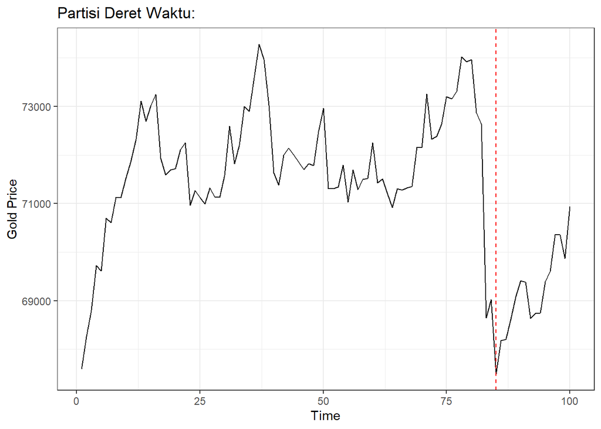

```r
plot_gold <- ts_prices |>
  as_tsibble() |>
  ggplot(aes(x = index, y = value)) +
  geom_line() +
  theme_bw() +
  xlab("Time") +
  ylab("Gold Price") +

  # Tambahkan garis batas
  geom_vline(xintercept = 85, linetype = "dashed", color = "red") +
  ggtitle("Partisi Deret Waktu:")

plot_gold
```

## **Plot Data Latih**

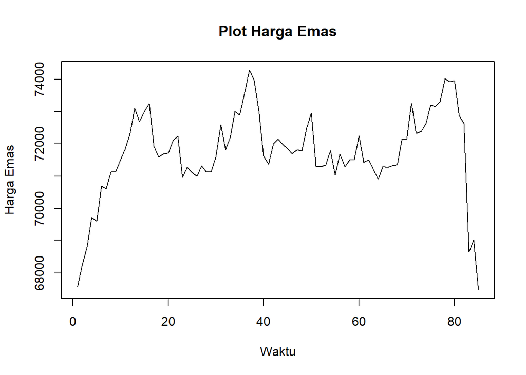

```r
plot.ts(train_ts, lty=1, xlab="Waktu", ylab="Harga Emas", main="Plot Harga Emas")
```

## **Plot Data Uji**

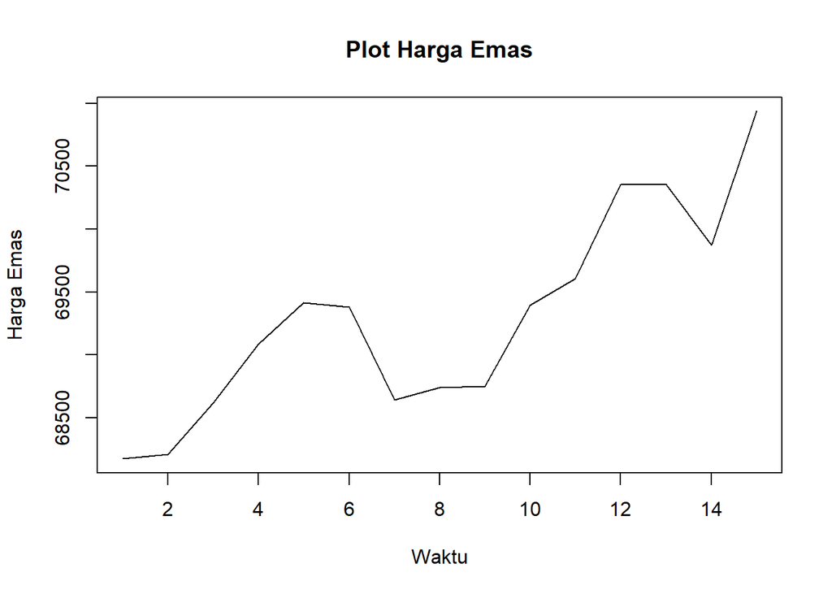

```r
plot.ts(test_ts, lty=1, xlab="Waktu", ylab="Harga Emas", main="Plot Harga Emas")
```

# **Periksa Kestasioneran**

## **Plot ACF**

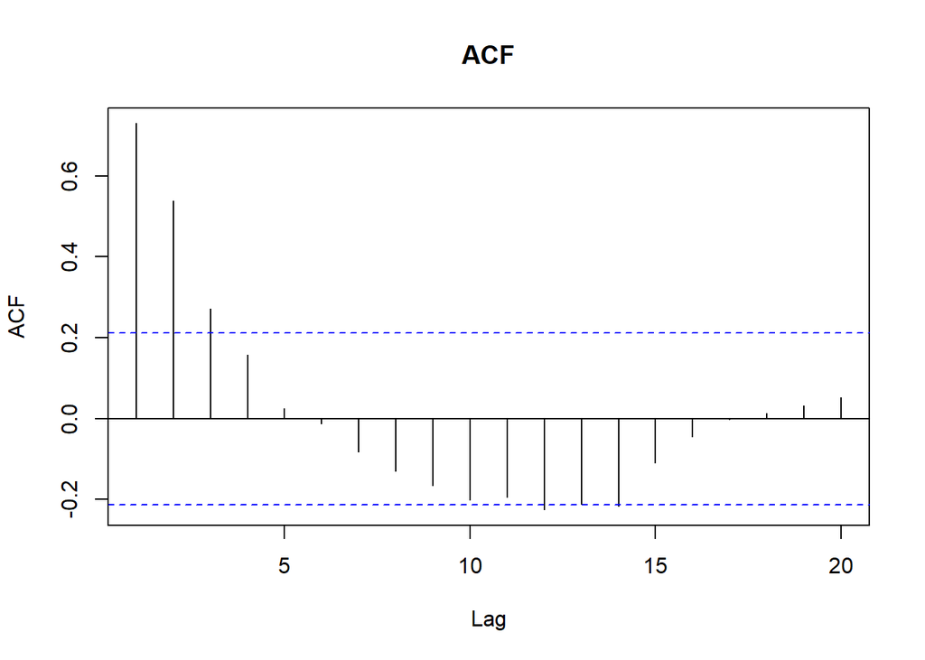

```r
acf(train_ts, main="ACF", lag.max=20)
```

Dari plot ACF, terlihat bahwa nilai autokorelasi **menurun secara perlahan** (*decaying slowly*) dan tidak langsung turun ke sekitar nol. Hal ini menjadi indikasi bahwa data **belum stasioner dalam rataan**.

## **Uji ADF**

```r
tseries::adf.test(train_ts)
```

```
##
##  Augmented Dickey-Fuller Test
##
## data:  train_ts
## Dickey-Fuller = -3.0579, Lag order = 4, p-value = 0.1418
## alternative hypothesis: stationary
```

$H_0$ : Data tidak stasioner dalam rataan

$H_1$ : Data stasioner dalam rataan

Berdasarkan uji ADF tersebut, didapat *p-value* sebesar **0.1418** yang lebih besar dari taraf nyata 5% sehingga tak tolak $H_0$ dan menandakan bahwa **data tidak stasioner dalam rataan**.

## **Plot Box-Cox**

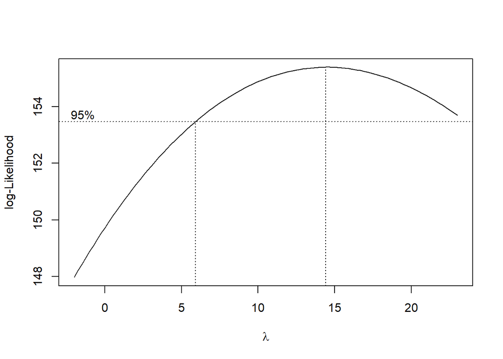

```r
bc = MASS::boxcox(train_ts ~ 1, lambda = seq(-2,23,by=1))
```

```r
#Nilai Rounded Lambda
lambda <- bc$x[which.max(bc$y)]
lambda
```

```
## [1] 14.41414
```

```r
#SK
bc$x[bc$y > max(bc$y) - 1/2 * qchisq(.95,1)]
```

```
##  [1]  6.080808  6.333333  6.585859  6.838384  7.090909  7.343434  7.595960
##  [8]  7.848485  8.101010  8.353535  8.606061  8.858586  9.111111  9.363636
## [15]  9.616162  9.868687 10.121212 10.373737 10.626263 10.878788 11.131313
## [22] 11.383838 11.636364 11.888889 12.141414 12.393939 12.646465 12.898990
## [29] 13.151515 13.404040 13.656566 13.909091 14.161616 14.414141 14.666667
## [36] 14.919192 15.171717 15.424242 15.676768 15.929293 16.181818 16.434343
## [43] 16.686869 16.939394 17.191919 17.444444 17.696970 17.949495 18.202020
## [50] 18.454545 18.707071 18.959596 19.212121 19.464646 19.717172 19.969697
## [57] 20.222222 20.474747 20.727273 20.979798 21.232323 21.484848 21.737374
## [64] 21.989899 22.242424 22.494949 22.747475 23.000000
```

## **Penanganan Ketidakstasioneran Rataan**

```r
# Karena tidak stasioner: lakukan differencing 1x
ts_diff1 <- diff(train_ts, differences = 1)
adf.test(ts_diff1)
```

```
## Augmented Dickey-Fuller Test
## alternative: stationary
##
## Type 1: no drift no trend
##      lag   ADF p.value
## [1,]   0 -9.36    0.01
## [2,]   1 -4.92    0.01
## [3,]   2 -4.22    0.01
## [4,]   3 -3.17    0.01
## Type 2: with drift no trend
##      lag   ADF p.value
## [1,]   0 -9.29  0.0100
## [2,]   1 -4.89  0.0100
## [3,]   2 -4.17  0.0100
## [4,]   3 -3.10  0.0334
## Type 3: with drift and trend
##      lag   ADF p.value
## [1,]   0 -9.77  0.0100
## [2,]   1 -5.19  0.0100
## [3,]   2 -4.45  0.0100
## [4,]   3 -3.41  0.0598
## ----
## Note: in fact, p.value = 0.01 means p.value <= 0.01
```

Hasil Uji ADF menunjukkan bahwa *p-value* bernilai sebesar **0.01**, yang lebih kecil dari taraf 5% sehingga dapat disimpulkan bahwa **data sudah stasioner dalam rataan**.

## **Perbandingan Setelah Differencing**

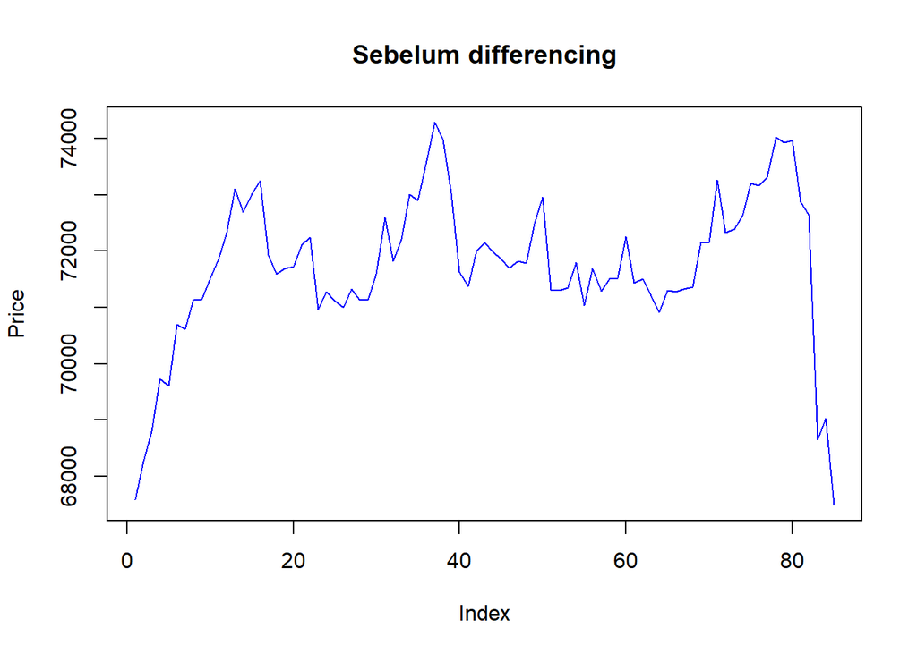

```r
# Plot sebelum dan sesudah differencing
plot(train_ts, type = "l", main="Sebelum differencing", ylab="Price", col="blue")
```

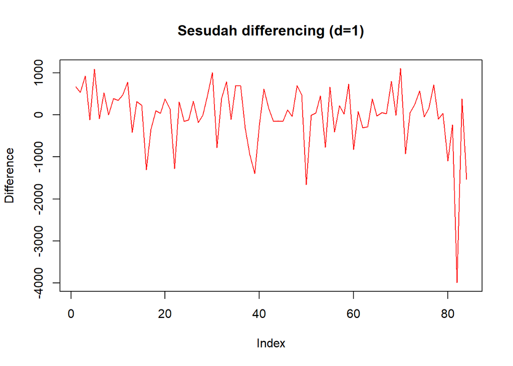

```r
plot(ts_diff1, type = "l", main="Sesudah differencing (d=1)", ylab="Difference", col="red")
```

```r
par(mfrow=c(1,1))
```

Dari plot perbanding, terlihat bahwa data sudah cukup **stasioner dalam rataan**.

```r
arch.test <- ArchTest(ts_diff1, lags = 12)
arch.test
```

```
##
##  ARCH LM-test; Null hypothesis: no ARCH effects
##
## data:  ts_diff1
## Chi-squared = 8.4541, df = 12, p-value = 0.7487
```

# **Spesifikasi Model**

## **Plot ACF & PACF**

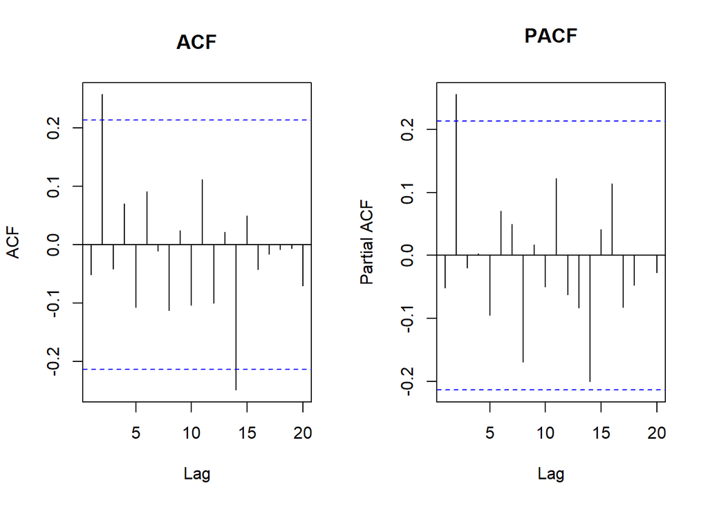

```r
par(mfrow = c(1,2))
acf(ts_diff1, main="ACF", lag.max=20) #ARIMA(0,0,2)
pacf(ts_diff1, main="PACF", lag.max=20) #ARIMA(1,0,0)
```

```r
par(mfrow = c(1,1))
```

## **Periksa EACF**

```r
eacf(ts_diff1)
```

```
## AR/MA
##   0 1 2 3 4 5 6 7 8 9 10 11 12 13
## 0 o x o o o o o o o o o  o  o  x
## 1 o o o o o o o o o o o  o  o  x
## 2 o o o o o o o o o o o  o  o  o
## 3 x o o o o o o o o o o  o  o  o
## 4 x x o o o o o o o o o  o  o  o
## 5 x x o o o o o o o o o  o  o  o
## 6 x o x o o x o o o o o  o  o  o
## 7 o x x o o x o o o o o  o  o  o
```

Tabel EACF menunjukkan banyak kombinasi model yang layak, sehingga diambil 6 model yakni: **ARIMA(1,1,0), ARIMA(0,1,1), ARIMA(1,1,1), ARIMA(2,1,0), ARIMA(0,1,3), ARIMA(2,1,1)**.

## **Pendugaan Parameter**

### **ARIMA (1,1,0)**

```r
ts_diff1 <- ts(ts_diff1)
model1=Arima(ts_diff1, order=c(1,1,0),method="ML")
summary(model1)
```

```
## Series: ts_diff1
## ARIMA(1,1,0)
##
## Coefficients:
##           ar1
##       -0.6520
## s.e.   0.0842
##
## sigma^2 = 655839:  log likelihood = -673.38
## AIC=1350.77   AICc=1350.92   BIC=1355.6
##
## Training set error measures:
##                     ME   RMSE      MAE      MPE     MAPE      MASE       ACF1
## Training set -28.15653 800.14 571.3569 196.1144 399.1623 0.7557149 -0.1625197
```

```r
lmtest::coeftest(model1)
```

```
##
## z test of coefficients:
##
##      Estimate Std. Error z value  Pr(>|z|)
## ar1 -0.652018   0.084174  -7.746 9.481e-15 ***
## ---
## Signif. codes:  0 '***' 0.001 '**' 0.01 '*' 0.05 '.' 0.1 ' ' 1
```

Nilai AIC 1350.77 dan parameter AR(1) signifikan.

### **ARIMA (0,1,1)**

```r
model2=Arima(ts_diff1, order=c(0,1,1),method="ML")
summary(model2)
```

```
## Series: ts_diff1
## ARIMA(0,1,1)
##
## Coefficients:
##           ma1
##       -0.9020
## s.e.   0.0976
##
## sigma^2 = 558701:  log likelihood = -667.29
## AIC=1338.59   AICc=1338.74   BIC=1343.43
##
## Training set error measures:
##                     ME     RMSE      MAE      MPE     MAPE      MASE       ACF1
## Training set -115.6573 738.5111 476.8088 285.2564 337.8497 0.6306593 -0.1532668
```

```r
lmtest::coeftest(model2)
```

```
##
## z test of coefficients:
##
##      Estimate Std. Error z value  Pr(>|z|)
## ma1 -0.902037   0.097638 -9.2386 < 2.2e-16 ***
## ---
## Signif. codes:  0 '***' 0.001 '**' 0.01 '*' 0.05 '.' 0.1 ' ' 1
```

Nilai AIC 1338.59 dan parameter MA(1) signifikan.

### **ARIMA (1,1,1)**

```r
model3=Arima(ts_diff1, order=c(1,1,1),method="ML")
summary(model3)
```

```
## Series: ts_diff1
## ARIMA(1,1,1)
##
## Coefficients:
##           ar1      ma1
##       -0.2530  -0.7455
## s.e.   0.1388   0.1219
##
## sigma^2 = 549697:  log likelihood = -665.88
## AIC=1337.76   AICc=1338.07   BIC=1345.02
##
## Training set error measures:
##                     ME     RMSE     MAE      MPE     MAPE      MASE
## Training set -89.65635 728.0557 482.065 323.6305 380.7123 0.6376114
##                      ACF1
## Training set -0.004066902
```

```r
lmtest::coeftest(model3)
```

```
##
## z test of coefficients:
##
##     Estimate Std. Error z value  Pr(>|z|)
## ar1 -0.25300    0.13879 -1.8229   0.06832 .
## ma1 -0.74548    0.12193 -6.1141 9.711e-10 ***
## ---
## Signif. codes:  0 '***' 0.001 '**' 0.01 '*' 0.05 '.' 0.1 ' ' 1
```

Nilai AIC 1337.76 dengan parameter AR(1) tidak signifikan dan MA(1) signifikan.

### **ARIMA (2,1,0)**

```r
model4=Arima(ts_diff1, order=c(2,1,0),method="ML")
summary(model4)
```

```
## Series: ts_diff1
## ARIMA(2,1,0)
##
## Coefficients:
##           ar1      ar2
##       -0.8220  -0.2959
## s.e.   0.1062   0.1187
##
## sigma^2 = 616814:  log likelihood = -670.4
## AIC=1346.8   AICc=1347.1   BIC=1354.06
##
## Training set error measures:
##                     ME     RMSE      MAE      MPE     MAPE     MASE        ACF1
## Training set -45.00965 771.2228 545.5855 339.8026 429.4473 0.721628 -0.08153811
```

```r
lmtest::coeftest(model4)
```

```
##
## z test of coefficients:
##
##     Estimate Std. Error z value  Pr(>|z|)
## ar1 -0.82200    0.10615 -7.7435 9.675e-15 ***
## ar2 -0.29591    0.11867 -2.4936   0.01265 *
## ---
## Signif. codes:  0 '***' 0.001 '**' 0.01 '*' 0.05 '.' 0.1 ' ' 1
```

Nilai AIC 1346.8 dan seluruh parameter signifikan.

### **ARIMA (0,1,3)**

```r
model5=Arima(ts_diff1, order = c(0,1,3), method = "ML")
summary(model5)
```

```
## Series: ts_diff1
## ARIMA(0,1,3)
##
## Coefficients:
##           ma1     ma2      ma3
##       -1.0076  0.3016  -0.2351
## s.e.   0.1077  0.1536   0.1157
##
## sigma^2 = 536155:  log likelihood = -664.8
## AIC=1337.59   AICc=1338.11   BIC=1347.27
##
## Training set error measures:
##                     ME     RMSE      MAE      MPE     MAPE      MASE
## Training set -124.8572 714.5791 463.5375 321.3918 363.9454 0.6131058
##                     ACF1
## Training set -0.04145569
```

```r
lmtest::coeftest(model5)
```

```
##
## z test of coefficients:
##
##     Estimate Std. Error z value Pr(>|z|)
## ma1 -1.00764    0.10766 -9.3592  < 2e-16 ***
## ma2  0.30160    0.15359  1.9636  0.04958 *
## ma3 -0.23509    0.11570 -2.0320  0.04216 *
## ---
## Signif. codes:  0 '***' 0.001 '**' 0.01 '*' 0.05 '.' 0.1 ' ' 1
```

Nilai AIC 1337.59 dan seluruh parameter signifikan.

### **ARIMA (2,1,1)**

```r
model6=Arima(ts_diff1, order = c(2,1,1), method = "ML")
summary(model6)
```

```
## Series: ts_diff1
## ARIMA(2,1,1)
##
## Coefficients:
##           ar1     ar2      ma1
##       -0.0546  0.2551  -0.9537
## s.e.   0.1186  0.1183   0.0577
##
## sigma^2 = 533654:  log likelihood = -664.6
## AIC=1337.2   AICc=1337.71   BIC=1346.87
##
## Training set error measures:
##                     ME     RMSE     MAE      MPE     MAPE      MASE        ACF1
## Training set -123.6176 712.9106 466.685 302.5947 349.7959 0.6172689 -0.03417579
```

```r
lmtest::coeftest(model6)
```

```
##
## z test of coefficients:
##
##      Estimate Std. Error  z value Pr(>|z|)
## ar1 -0.054602   0.118560  -0.4605  0.64513
## ar2  0.255128   0.118261   2.1573  0.03098 *
## ma1 -0.953727   0.057683 -16.5338  < 2e-16 ***
## ---
## Signif. codes:  0 '***' 0.001 '**' 0.01 '*' 0.05 '.' 0.1 ' ' 1
```

Nilai AIC 1337.2 dengan parameter AR(1) tidak signifikan dan parameter lainnya signifikan.

# **Eksplorasi Sisaan**

```r
#Eksplorasi
sisaan <- model5$residuals
par(mfrow=c(2,3))
qqnorm(sisaan)
qqline(sisaan, col = "blue", lwd = 2)
car::qqPlot(sisaan)
```

```
## [1] 82 50
```

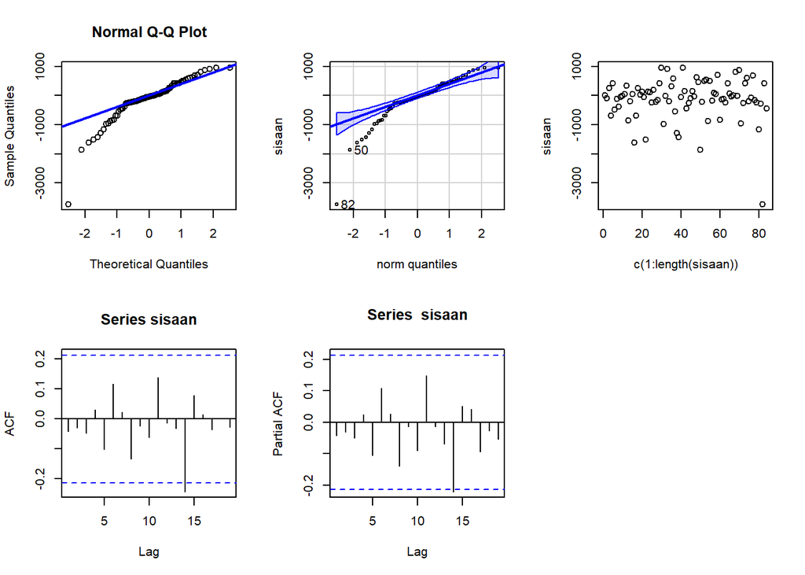

```r
plot(c(1:length(sisaan)),sisaan)
acf(sisaan)
pacf(sisaan)
par(mfrow = c(1,1))
```

## **Uji Formal**

### **Asumsi 1: Sisaan Menyebar Normal**

```r
ks.test(sisaan,"pnorm")
```

```
##
##  Exact one-sample Kolmogorov-Smirnov test
##
## data:  sisaan
## D = 0.55887, p-value < 2.2e-16
## alternative hypothesis: two-sided
```

$H_0$ : Sisaan menyebar normal

$H_1$ : Sisaan tidak menyebar normal

Berdasarkan uji KS tersebut, didapat *p-value* < 0.05 yang lebih kecil dari taraf nyata 5% sehingga tolak $H_0$ dan menandakan bahwa sisaan tidak menyebar normal. Hal ini sesuai dengan hasil eksplorasi menggunakan plot kuantil-kuantil normal.

### **Asumsi 2: Tidak Ada Autokorelasi**

```r
Box.test(sisaan, type = "Ljung")
```

```
##
##  Box-Ljung test
##
## data:  sisaan
## X-squared = 0.14958, df = 1, p-value = 0.6989
```

$H_0$ : Sisaan saling bebas

$H_1$ : Sisaan tidak tidak saling bebas

Berdasarkan uji Ljung-Box tersebut, didapat *p-value* sebesar 0.6989 yang lebih besar dari taraf nyata 5% sehingga tak tolak $H_0$ dan menandakan bahwa sisaan saling bebas. Hal ini berbeda dengan hasil eksplorasi.

### **Asumsi 3: Sisaan Homogen**

```r
Box.test((sisaan)^2, type = "Ljung")
```

```
##
##  Box-Ljung test
##
## data:  (sisaan)^2
## X-squared = 0.14475, df = 1, p-value = 0.7036
```

$H_0$ : Ragam sisaan homogen

$H_1$ : Ragam sisaan tidak homogen

Berdasarkan uji Ljung-Box terhadap sisaan kuadrat tersebut, didapat *p-value* sebesar 0.7036 yang lebih besar dari taraf nyata 5% sehingga tak tolak $H_0$ dan menandakan bahwa ragam sisaan homogen. Hal ini sejalan dengan hasil eksplorasi.

### **Asumsi 4: Nilai Tengah Sisaan = 0**

```r
t.test(sisaan, mu = 0, conf.level = 0.95)
```

```
##
##  One Sample t-test
##
## data:  sisaan
## t = -1.6167, df = 83, p-value = 0.1097
## alternative hypothesis: true mean is not equal to 0
## 95 percent confidence interval:
##  -278.46193   28.74745
## sample estimates:
## mean of x
## -124.8572
```

$H_0$ : nilai tengah sisaan sama dengan 0

$H_1$ : nilai tengah sisaan tidak sama dengan 0

Berdasarkan uji-ttersebut, didapat *p-value* sebesar 0.1097 yang lebih besar dari taraf nyata 5% sehingga tak tolak $H_0$ dan menandakan bahwa nilai tengah sisaan sama dengan nol. Hal ini sesuai dengan hasil eksplorasi.

Hasil uji formal menunujukkan bahwa data **sudah memenuhi seluruh asumsi kecuali 1**, dimana sisaan tidak menyebar normal.

# **Overfitting**

```r
model1a=Arima(ts_diff1, order=c(1,1,3),method="ML")
summary(model1a)
```

```
## Series: ts_diff1
## ARIMA(1,1,3)
##
## Coefficients:
##           ar1      ma1      ma2      ma3
##       -0.8043  -0.1875  -0.5494  -0.1332
## s.e.   0.1765   0.2091   0.1978   0.1282
##
## sigma^2 = 538459:  log likelihood = -664.46
## AIC=1338.92   AICc=1339.7   BIC=1351.01
##
## Training set error measures:
##                     ME     RMSE      MAE      MPE     MAPE      MASE
## Training set -119.5426 711.6235 466.3988 215.0881 269.2375 0.6168903
##                     ACF1
## Training set -0.03769237
```

```r
lmtest::coeftest(model1a)
```

```
##
## z test of coefficients:
##
##     Estimate Std. Error z value  Pr(>|z|)
## ar1 -0.80431    0.17651 -4.5567 5.196e-06 ***
## ma1 -0.18750    0.20912 -0.8966  0.369942
## ma2 -0.54941    0.19780 -2.7776  0.005477 **
## ma3 -0.13320    0.12823 -1.0387  0.298950
## ---
## Signif. codes:  0 '***' 0.001 '**' 0.01 '*' 0.05 '.' 0.1 ' ' 1
```

```r
model1b=Arima(ts_diff1, order=c(0,1,4),method="ML")
summary(model1b)
```

```
## Series: ts_diff1
## ARIMA(0,1,4)
##
## Coefficients:
##           ma1     ma2      ma3     ma4
##       -1.0082  0.3020  -0.2370  0.0023
## s.e.   0.1108  0.1549   0.1435  0.1060
##
## sigma^2 = 542950:  log likelihood = -664.8
## AIC=1339.59   AICc=1340.37   BIC=1351.69
##
## Training set error measures:
##                     ME     RMSE      MAE    MPE     MAPE      MASE        ACF1
## Training set -124.8524 714.5846 463.4034 320.95 363.5674 0.6129284 -0.04085595
```

```r
lmtest::coeftest(model1b)
```

```
##
## z test of coefficients:
##
##       Estimate Std. Error z value Pr(>|z|)
## ma1 -1.0082327  0.1107723 -9.1018  < 2e-16 ***
## ma2  0.3019761  0.1548803  1.9497  0.05121 .
## ma3 -0.2369629  0.1435443 -1.6508  0.09878 .
## ma4  0.0023344  0.1060245  0.0220  0.98243
## ---
## Signif. codes:  0 '***' 0.001 '**' 0.01 '*' 0.05 '.' 0.1 ' ' 1
```

# **Peramalan**

```r
ramalan <- forecast::forecast(model5, h = 15)
ramalan
```

```
##    Point Forecast     Lo 80    Hi 80     Lo 95    Hi 95
## 85      -92.20839 -1030.602 846.1850 -1527.357 1342.940
## 86     -321.06560 -1259.485 617.3543 -1756.255 1114.124
## 87     -218.20868 -1196.334 759.9167 -1714.122 1277.705
## 88     -218.20868 -1197.893 761.4752 -1716.506 1280.088
## 89     -218.20868 -1199.448 763.0311 -1718.885 1282.468
## 90     -218.20868 -1201.002 764.5846 -1721.261 1284.844
## 91     -218.20868 -1202.553 766.1356 -1723.633 1287.216
## 92     -218.20868 -1204.102 767.6842 -1726.002 1289.584
## 93     -218.20868 -1205.648 769.2304 -1728.366 1291.949
## 94     -218.20868 -1207.191 770.7741 -1730.727 1294.310
## 95     -218.20868 -1208.733 772.3155 -1733.085 1296.667
## 96     -218.20868 -1210.272 773.8544 -1735.438 1299.021
## 97     -218.20868 -1211.808 775.3910 -1737.788 1301.371
## 98     -218.20868 -1213.343 776.9252 -1740.135 1303.717
## 99     -218.20868 -1214.874 778.4570 -1742.477 1306.060
```

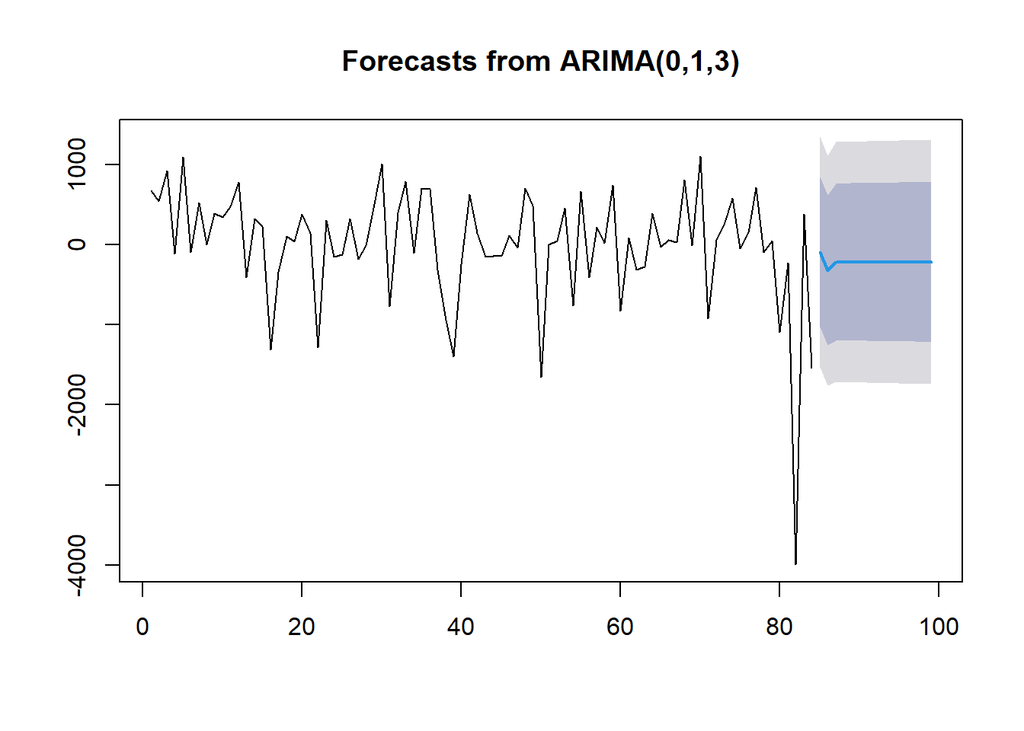

```r
data.ramalan <- ramalan$mean
plot(ramalan)
```

```r
perbandingan<-matrix(data=c(test_ts, data.ramalan),
                     nrow = 15, ncol = 2)
colnames(perbandingan)<-c("Aktual","Hasil Forecast")
perbandingan
```

```
##       Aktual Hasil Forecast
##  [1,]  68173      -92.20839
##  [2,]  68206     -321.06560
##  [3,]  68617     -218.20868
##  [4,]  69083     -218.20868
##  [5,]  69412     -218.20868
##  [6,]  69381     -218.20868
##  [7,]  68641     -218.20868
##  [8,]  68742     -218.20868
##  [9,]  68752     -218.20868
## [10,]  69396     -218.20868
## [11,]  69604     -218.20868
## [12,]  70354     -218.20868
## [13,]  70356     -218.20868
## [14,]  69874     -218.20868
## [15,]  70938     -218.20868
```

```r
accuracy(data.ramalan, test_ts)
```

```
##               ME     RMSE     MAE      MPE     MAPE
## Test set 69518.6 69523.14 69518.6 100.3126 100.3126
```

# **Kesimpulan**